# Climate Risk Index (CRI) Methodology Comparison

## Objective

The goal is to analyze how the changes in periods of analysis and data sources impact CRI scores.

## Methodology Overview

Both phases utilize the same scoring logic based on the Germanwatch Global Climate Risk Index:

### 1. Indicators and Weights

| Category | Indicator | Weight |
| --- | --- | --- |
| **Human Impact (50%)** | Total Deaths (Absolute) | 7.5% |
|  | Death Rate (per 100k population) | 22.5% |
|  | Total Affected (Absolute) | 5.0% |
|  | Affected Rate (per 100k population) | 15.0% |
| **Economic Impact (50%)** | Total Economic Loss (Absolute) | 12.5% |
|  | Loss per Unit GPP | 37.5% |

### 2. Normalization

All indicators are normalized using **Min-Max Scaling** to a range of [0, 1]. $$S_i = \frac{X_i - X_{min}}{X_{max} - X_{min}}$$

### 3. Final Score

The final CRI score is the weighted sum of normalized indicators: $$CRI = \sum_{j=1}^{6} w_j S_j$$ *Note: Higher scores indicate higher climate risk.*

## Data Lineage

### 1. Pilot Phase Datasets (2559-2566)

- **Human Impact**: `casualties_by_hazard_2559_2566.csv` (TEI got data from DDPM). Measures `deaths` and `injuries` across four hazards (Flood, Drought, Windstorm, Landslide).
- **Economic Impact**: `relief_by_hazard_2559_2566.csv` (TEI got data the Office of Agricultural Economics). Based on OAE agricultural relief data.
- **Denominators**: `population_avg_2559_2566.csv` from DOPA and `gpp_avg_2559_2566.csv` from NESDC. GPP is gross provincial productivity.

### 2. Phase 1 Datasets (2560-2567)

- **Human Impact**: `fact_ddpm_tambon_impact_climate_2560_2567.csv` (Gold). Derived from standardized DDPM village-level disaster reports.
  - Bronze `สถิติการเกิดสาธารณะภัยรายหมู่บ้าน Open Data`
- **Economic Impact**: `silver_govt_adv_payment_annual_long.csv` (Silver). Public financial proxy using government advance payments for disasters.
  - Bronze `สถิติข้อมูลการใช้จ่ายเงินทดรองราชการ ปี 2546 - ปัจจุบัน.xlsx`
- **Denominators**: `silver_population_annual.csv` (Silver - DOPA) and `silver_gpp_annual_long.csv` (Silver - NESDC). GPP covers the total economy at current market prices.
  - Bronze `GPP-2024-On-Web-1995-2024.xlsx`

```python
import pandas as pd
import numpy as np
import os
import matplotlib.pyplot as plt
import seaborn as sns

# Configuration
DATA_DIR = "../../data"
PILOT_DIR = os.path.join(DATA_DIR, "0_bronze/tei_pilot")
PHASE1_GOLD_DIR = os.path.join(DATA_DIR, "2_gold/ddpm")
PHASE1_SILVER_DIR = os.path.join(DATA_DIR, "1_silver")

pd.options.display.max_columns = None
plt.rcParams['font.family'] = 'Tahoma'
plt.rcParams['axes.unicode_minus'] = False
```

## 1. Pilot Data Ingestion & Processing (2559-2566)

We load the four core Pilot datasets provided by TEI.

```python
# Load Pilot Data
pilot_casualties = pd.read_csv(os.path.join(PILOT_DIR, "casualties_by_hazard_2559_2566.csv"))
pilot_relief = pd.read_csv(os.path.join(PILOT_DIR, "relief_by_hazard_2559_2566.csv"))
pilot_pop = pd.read_csv(os.path.join(PILOT_DIR, "population_avg_2559_2566.csv"))
pilot_gpp = pd.read_csv(os.path.join(PILOT_DIR, "gpp_avg_2559_2566.csv"))

# 1.0 Province Name Normalization (Applied immediately after loading)
def normalize_province(name):
    if not isinstance(name, str): return name
    name = name.strip()
    if name == "กรุงเทพ": return "กรุงเทพมหานคร"
    if name.startswith("จังหวัด"):
        name = name.replace("จังหวัด", "")
    return name

for df in [pilot_casualties, pilot_relief, pilot_pop, pilot_gpp]:
    df["province_name_th"] = df["province_name_th"].apply(normalize_province)

print(f"Pilot Casualties: {pilot_casualties.shape}")
print(f"Pilot Relief: {pilot_relief.shape}")
print(f"Pilot Population: {pilot_pop.shape}")
print(f"Pilot GPP: {pilot_gpp.shape}")
```

```
Pilot Casualties: (308, 5)
Pilot Relief: (308, 4)
Pilot Population: (77, 2)
Pilot GPP: (77, 2)
```

```python
# 1.1 Pilot Aggregation (2559-2566)
# Per methodology: Pilot uses Agricultural GPP as the denominator for Economic Loss (OAE Relief).
# Human Impact 'Affected' is defined as Deaths + Injured.

# 1. Aggregate Impact Metrics (Sum hazards per province)
pilot_impact = pilot_casualties.groupby("province_name_th").agg({
    "deaths_count_avg_2559_2566": "sum",
    "injured_count_avg_2559_2566": "sum"
}).merge(
    pilot_relief.groupby("province_name_th")["relief_amount_avg_2559_2566_baht"].sum(),
    on="province_name_th", how="outer"
).fillna(0)

# 2. Aggregate Denominators (Mean population and GPP)
pilot_den = pilot_pop.groupby("province_name_th")["population_avg_2559_2566"].mean().to_frame().merge(
    pilot_gpp.groupby("province_name_th")["gpp_avg_2559_2566"].mean(),
    on="province_name_th", how="outer"
)

# 3. Final Merge and Standardization
pilot_df = pilot_den.merge(pilot_impact, on="province_name_th", how="outer").fillna(0).reset_index()

pilot_df = pilot_df.rename(columns={
    "population_avg_2559_2566": "pop",
    "gpp_avg_2559_2566": "gpp_agri_pilot",  # Clarified: Agricultural GPP (M THB)
    "deaths_count_avg_2559_2566": "deaths_abs",
    "injured_count_avg_2559_2566": "injured_abs",
    "relief_amount_avg_2559_2566_baht": "loss_abs"
})

# 4. Calculate Composite & Rate Metrics
pilot_df["affected_abs"] = pilot_df["deaths_abs"] + pilot_df["injured_abs"]

pilot_df["death_rate"]    = (pilot_df["deaths_abs"] / pilot_df["pop"]) * 100_000
pilot_df["affected_rate"] = (pilot_df["affected_abs"] / pilot_df["pop"]) * 100_000
pilot_df["loss_rate"]     = pilot_df["loss_abs"] / (pilot_df["gpp_agri_pilot"] * 1_000_000)

pilot_df.head()
```

|  | province_name_th | pop | gpp_agri_pilot | deaths_abs | injured_abs | loss_abs | affected_abs | death_rate | affected_rate | loss_rate |
| --- | --- | --- | --- | --- | --- | --- | --- | --- | --- | --- |
| 0 | กระบี่ | 473639.875 | 24507.68000 | 0.750 | 6066.050 | 2.087871e+05 | 6066.800 | 0.158348 | 1280.888777 | 0.000009 |
| 1 | กรุงเทพมหานคร | 5497670.500 | 2213.69125 | 0.000 | 90.775 | 2.731562e+05 | 90.775 | 0.000000 | 1.651154 | 0.000123 |
| 2 | กาญจนบุรี | 815728.750 | 25624.48625 | 0.250 | 38307.000 | 4.090072e+07 | 38307.250 | 0.030647 | 4696.076974 | 0.001596 |
| 3 | กาฬสินธุ์ | 978258.500 | 14150.39875 | 0.625 | 48724.250 | 8.363617e+07 | 48724.875 | 0.063889 | 4980.777065 | 0.005911 |
| 4 | กำแพงเพชร | 717539.125 | 23546.20875 | 0.500 | 36470.100 | 5.248029e+07 | 36470.600 | 0.069683 | 5082.733293 | 0.002229 |

```python
## 1.2 Pilot Normalization & Scoring
def calculate_cri(df, prefix=""):
    # Standard columns expected in input DF (no prefix)
    base_cols = ["deaths_abs", "death_rate", "affected_abs", "affected_rate", "loss_abs", "loss_rate"]
    # Correct CRI weights
    weights = [0.075, 0.225, 0.05, 0.15, 0.125, 0.375]

    normalized_df = df.copy()
    for col in base_cols:
        s = pd.to_numeric(df[col], errors='coerce').fillna(0.0)
        mn, mx = s.min(), s.max()
        if mx > mn:
            normalized_df[f"score_{col}"] = (s - mn) / (mx - mn)
        else:
            normalized_df[f"score_{col}"] = 0.0

    norm_cols = [f"score_{col}" for col in base_cols]
    # Final score column with requested prefix
    normalized_df[f"{prefix}cri_score"] = (normalized_df[norm_cols] * weights).sum(axis=1)
    return normalized_df

pilot_scored = calculate_cri(pilot_df, prefix="pilot_")
pilot_scored["pilot_rank"] = pilot_scored["pilot_cri_score"].rank(ascending=False)
pilot_scored.sort_values("pilot_rank").head(10)
```

|  | province_name_th | pop | gpp_agri_pilot | deaths_abs | injured_abs | loss_abs | affected_abs | death_rate | affected_rate | loss_rate | score_deaths_abs | score_death_rate | score_affected_abs | score_affected_rate | score_loss_abs | score_loss_rate | pilot_cri_score | pilot_rank |
| --- | --- | --- | --- | --- | --- | --- | --- | --- | --- | --- | --- | --- | --- | --- | --- | --- | --- | --- |
| 10 | ชัยภูมิ | 1127928.000 | 18079.33500 | 1.000 | 66731.925 | 6.528216e+08 | 66732.925 | 0.088658 | 5916.417094 | 0.036109 | 0.238095 | 0.067555 | 0.186433 | 0.116101 | 0.821460 | 1.000000 | 0.537476 | 1.0 |
| 5 | ขอนแก่น | 1792380.125 | 22035.37375 | 3.625 | 125208.250 | 5.542284e+08 | 125211.875 | 0.202245 | 6985.787962 | 0.025152 | 0.863095 | 0.154106 | 0.349889 | 0.137091 | 0.697398 | 0.696556 | 0.485847 | 2.0 |
| 18 | นครราชสีมา | 2631690.875 | 43429.37750 | 2.200 | 108080.750 | 7.947091e+08 | 108082.950 | 0.083596 | 4106.977420 | 0.018299 | 0.523810 | 0.063698 | 0.302012 | 0.080583 | 1.000000 | 0.506772 | 0.395845 | 3.0 |
| 13 | ตราด | 219067.625 | 19516.38625 | 2.875 | 33668.250 | 7.020177e+05 | 33671.125 | 1.312380 | 15370.196760 | 0.000036 | 0.684524 | 1.000000 | 0.094021 | 0.301668 | 0.000883 | 0.000996 | 0.326775 | 4.0 |
| 44 | ร้อยเอ็ด | 1298737.375 | 15901.87375 | 2.125 | 21375.625 | 2.922807e+08 | 21377.750 | 0.163620 | 1646.041025 | 0.018380 | 0.505952 | 0.124675 | 0.059659 | 0.032278 | 0.367783 | 0.509026 | 0.310680 | 5.0 |
| 40 | ยโสธร | 535141.000 | 7653.65375 | 1.000 | 22319.125 | 1.346468e+08 | 22320.125 | 0.186867 | 4170.886738 | 0.017592 | 0.238095 | 0.142388 | 0.062294 | 0.081838 | 0.169429 | 0.487209 | 0.269167 | 6.0 |
| 37 | มหาสารคาม | 953911.250 | 13255.06625 | 2.375 | 28724.825 | 1.672949e+08 | 28727.200 | 0.248975 | 3011.517057 | 0.012621 | 0.565476 | 0.189713 | 0.080202 | 0.059081 | 0.210511 | 0.349534 | 0.255357 | 7.0 |
| 20 | นครสวรรค์ | 1045762.125 | 32332.71875 | 0.750 | 62947.750 | 3.674431e+08 | 62948.500 | 0.071718 | 6019.389926 | 0.011364 | 0.178571 | 0.054647 | 0.175855 | 0.118122 | 0.462362 | 0.314728 | 0.228018 | 8.0 |
| 76 | แม่ฮ่องสอน | 239347.875 | 6715.90750 | 0.625 | 121939.500 | 2.781711e+06 | 121940.125 | 0.261126 | 50946.817472 | 0.000414 | 0.148810 | 0.198971 | 0.340745 | 1.000000 | 0.003500 | 0.011471 | 0.227706 | 9.0 |
| 67 | อุทัยธานี | 326451.125 | 10195.55750 | 0.375 | 11886.875 | 1.532275e+08 | 11887.250 | 0.114872 | 3641.356727 | 0.015029 | 0.089286 | 0.087529 | 0.033132 | 0.071444 | 0.192810 | 0.416211 | 0.218944 | 10.0 |

## 2. Phase 1 Data Ingestion & Processing (2560-2567)

We load the silver and gold tables developed for Phase 1.

```python
# Load Phase 1 Data
p1_ddpm = pd.read_csv(os.path.join(PHASE1_GOLD_DIR, "fact_ddpm_tambon_impact_climate_2560_2567.csv"))
p1_eco = pd.read_csv(os.path.join(PHASE1_SILVER_DIR, "govt_adv_payment/silver_govt_adv_payment_annual_long.csv"))
p1_gpp = pd.read_csv(os.path.join(PHASE1_SILVER_DIR, "gpp/silver_gpp_annual_long.csv"))
p1_pop = pd.read_csv(os.path.join(PHASE1_SILVER_DIR, "population/silver_population_annual.csv"))

# 2.0 Province Name Normalization (Applied immediately after loading)
for df in [p1_ddpm, p1_eco, p1_gpp, p1_pop]:
    df["province_name_th"] = df["province_name_th"].apply(normalize_province)

print(f"Phase 1 DDPM: {p1_ddpm.shape}")
print(f"Phase 1 Eco Loss: {p1_eco.shape}")
print(f"Phase 1 GPP: {p1_gpp.shape}")
print(f"Phase 1 Population: {p1_pop.shape}")
```

```
Phase 1 DDPM: (6967, 13)
Phase 1 Eco Loss: (1848, 23)
Phase 1 GPP: (1848, 24)
Phase 1 Population: (91104, 25)
```

```python
# 2.1 Phase 1 Aggregation (2560-2567)
# Per user instruction: Phase 1 uses Affected Households as a proxy for social impact.
# Metrics are averaged over the 8-year analysis period (2560-2567).

# 1. Aggregate Human Impact (Sum villages -> sum period -> average annually)
p1_human_agg = p1_ddpm.groupby("province_name_th").agg({
    "deaths_sum": "sum",
    "affected_households_sum": "sum"
}) / 8.0

# 2. Aggregate Economic Impact (Average of annual provincial relief sums)
p1_eco_agg = p1_eco.groupby(["province_name_th", "year_be"])["value"].sum() \
                  .groupby("province_name_th").mean() \
                  .to_frame(name="loss_abs")

# 3. Aggregate Denominators (Average over period)
p1_gpp_avg = p1_gpp[p1_gpp["metric_code"].str.contains("GPP_CURRENT_MARKET_PRICE", na=False)] \
                .groupby("province_name_th")["value"].mean() \
                .to_frame(name="gpp_total_p1")

p1_pop_avg = p1_pop[p1_pop["geography_level"].str.contains("province", case=False, na=False)] \
                .groupby("province_name_th")["population_total"].mean() \
                .to_frame(name="pop")

# 4. Final Merge & Standardization
p1_df = p1_pop_avg.join([p1_gpp_avg, p1_human_agg, p1_eco_agg], how="outer") \
                  .fillna(0).reset_index()

p1_df = p1_df.rename(columns={
    "deaths_sum": "deaths_abs",
    "affected_households_sum": "affected_abs"
})

# 5. Calculate Rates
p1_df["death_rate"]    = (p1_df["deaths_abs"] / p1_df["pop"]) * 100_000
p1_df["affected_rate"] = (p1_df["affected_abs"] / p1_df["pop"]) * 100_000
# Phase 1 GPP is in Million Baht
p1_df["loss_rate"]     = p1_df["loss_abs"] / (p1_df["gpp_total_p1"] * 1_000_000)

p1_df.head()
```

|  | province_name_th | pop | gpp_total_p1 | deaths_abs | affected_abs | loss_abs | death_rate | affected_rate | loss_rate |
| --- | --- | --- | --- | --- | --- | --- | --- | --- | --- |
| 0 | กระบี่ | 477925.000 | 8.210287e+04 | 0.750 | 1142.625 | 1.044652e+07 | 0.156928 | 239.080400 | 0.000127 |
| 1 | กรุงเทพมหานคร | 5570385.375 | 5.620290e+06 | 0.000 | 42.500 | 8.296531e+07 | 0.000000 | 0.762963 | 0.000015 |
| 2 | กาญจนบุรี | 893575.000 | 1.130313e+05 | 0.250 | 4963.875 | 7.623957e+06 | 0.027978 | 555.507372 | 0.000067 |
| 3 | กาฬสินธุ์ | 976265.500 | 6.168501e+04 | 0.500 | 10636.125 | 5.903598e+06 | 0.051216 | 1089.470538 | 0.000096 |
| 4 | กำแพงเพชร | 715456.625 | 1.186721e+05 | 0.375 | 2038.875 | 1.493133e+07 | 0.052414 | 284.975347 | 0.000126 |

```python
## 2.2 Phase 1 Normalization & Scoring
# We use the same calculate_cri function defined in Section 1.2
p1_scored = calculate_cri(p1_df, prefix="p1_")
p1_scored["p1_rank"] = p1_scored["p1_cri_score"].rank(ascending=False)
p1_scored.sort_values("p1_rank").head(10)
```

|  | province_name_th | pop | gpp_total_p1 | deaths_abs | affected_abs | loss_abs | death_rate | affected_rate | loss_rate | score_deaths_abs | score_death_rate | score_affected_abs | score_affected_rate | score_loss_abs | score_loss_rate | p1_cri_score | p1_rank |
| --- | --- | --- | --- | --- | --- | --- | --- | --- | --- | --- | --- | --- | --- | --- | --- | --- | --- |
| 76 | แม่ฮ่องสอน | 284846.125 | 15684.673717 | 0.625 | 4362.625 | 5.754977e+07 | 0.219417 | 1531.572529 | 0.003669 | 0.208333 | 0.190977 | 0.068232 | 0.430529 | 0.290669 | 1.000000 | 0.537920 | 1.0 |
| 19 | นครศรีธรรมราช | 1550082.500 | 180610.143601 | 2.625 | 26753.000 | 1.979342e+08 | 0.169346 | 1725.908137 | 0.001096 | 0.875000 | 0.147396 | 0.421863 | 0.485185 | 1.000000 | 0.298672 | 0.429662 | 2.0 |
| 13 | ตราด | 228476.250 | 46211.368823 | 2.625 | 711.000 | 6.382714e+06 | 1.148916 | 311.192082 | 0.000138 | 0.875000 | 1.000000 | 0.010558 | 0.087306 | 0.032134 | 0.037629 | 0.322376 | 3.0 |
| 29 | ปัตตานี | 727438.625 | 50855.973673 | 3.000 | 6593.500 | 3.996140e+07 | 0.412406 | 906.399492 | 0.000786 | 1.000000 | 0.358952 | 0.103466 | 0.254704 | 0.201799 | 0.214144 | 0.304672 | 4.0 |
| 71 | เชียงใหม่ | 1781519.875 | 257582.638287 | 2.375 | 63358.125 | 1.749528e+07 | 0.133313 | 3556.408541 | 0.000068 | 0.791667 | 0.116034 | 1.000000 | 1.000000 | 0.088283 | 0.018496 | 0.303454 | 5.0 |
| 22 | นราธิวาส | 809762.625 | 44903.887045 | 0.875 | 18659.875 | 3.641977e+07 | 0.108056 | 2304.363578 | 0.000811 | 0.291667 | 0.094051 | 0.294041 | 0.647871 | 0.183904 | 0.221036 | 0.260795 | 6.0 |
| 14 | ตาก | 673232.750 | 63929.976651 | 0.500 | 4185.625 | 8.570491e+07 | 0.074269 | 621.720349 | 0.001341 | 0.166667 | 0.064642 | 0.065436 | 0.174640 | 0.432931 | 0.365361 | 0.247639 | 7.0 |
| 59 | สุราษฎร์ธานี | 1069424.875 | 211994.046867 | 2.250 | 9158.000 | 6.357287e+07 | 0.210393 | 856.348138 | 0.000300 | 0.750000 | 0.183123 | 0.143969 | 0.240627 | 0.321103 | 0.081716 | 0.211527 | 8.0 |
| 23 | น่าน | 475928.000 | 35861.354266 | 1.875 | 3938.625 | 1.269978e+07 | 0.393967 | 827.567405 | 0.000354 | 0.625000 | 0.342903 | 0.061535 | 0.232533 | 0.064053 | 0.096503 | 0.206180 | 9.0 |
| 33 | พัทลุง | 522755.125 | 39992.291442 | 1.000 | 2943.250 | 3.531714e+07 | 0.191294 | 563.026522 | 0.000883 | 0.333333 | 0.166500 | 0.045814 | 0.158133 | 0.178333 | 0.240669 | 0.201016 | 10.0 |

## 3. Data exploration

### 3.1 Population Statistics Sanity Check

We compare the average population of each province between the Pilot phase (2559-2566) and Phase 1 (2560-2567). While impact variables can vary significantly year-over-year, the provincial population should remain relatively stable. Significant deviations (e.g., >5% change) may indicate data source discrepancies or boundary alignment issues.

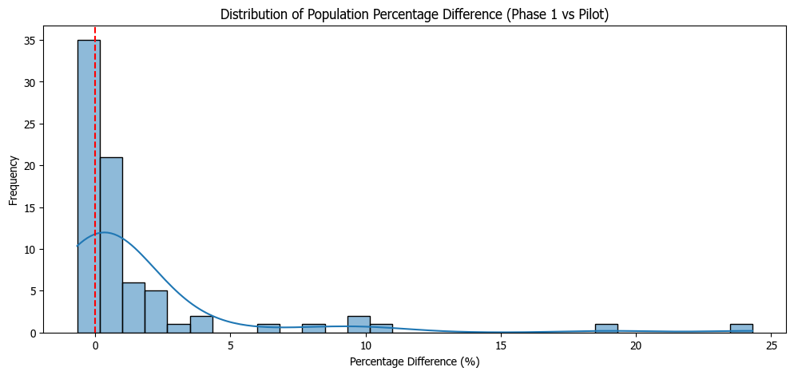

```
Provinces with > 5% population deviation:
```

|  | province_name_th | pop_p1 | pop_pilot | pop_ratio | pop_pct_diff |
| --- | --- | --- | --- | --- | --- |
| 14 | ตาก | 673232.750 | 541570.750 | 1.243111 | 24.311136 |
| 76 | แม่ฮ่องสอน | 284846.125 | 239347.875 | 1.190093 | 19.009256 |
| 70 | เชียงราย | 1295971.250 | 1168574.875 | 1.109019 | 10.901858 |
| 71 | เชียงใหม่ | 1781519.875 | 1625048.875 | 1.096287 | 9.628695 |
| 2 | กาญจนบุรี | 893575.000 | 815728.750 | 1.095432 | 9.543154 |
| 41 | ระนอง | 193138.250 | 178264.750 | 1.083435 | 8.343489 |
| 54 | สมุทรสาคร | 584556.000 | 547908.750 | 1.066886 | 6.688568 |

```
Average Population Ratio: 1.0164
Median Population Ratio: 1.0044
```

```python
# Population Sanity Check
pop_check = p1_df[['province_name_th', 'pop']].merge(
    pilot_df[['province_name_th', 'pop']],
    on='province_name_th',
    suffixes=('_p1', '_pilot')
)

pop_check['pop_ratio'] = pop_check['pop_p1'] / pop_check['pop_pilot']
pop_check['pop_pct_diff'] = (pop_check['pop_ratio'] - 1) * 100

# Visualize Distribution
plt.figure(figsize=(12, 5))
sns.histplot(pop_check['pop_pct_diff'], bins=30, kde=True)
plt.axvline(0, color='red', linestyle='--')
plt.title("Distribution of Population Percentage Difference (Phase 1 vs Pilot)")
plt.xlabel("Percentage Difference (%)")
plt.ylabel("Frequency")
plt.show()

# Identify Outliers (> 5% deviation)
outliers = pop_check[pop_check['pop_pct_diff'].abs() > 5].sort_values('pop_pct_diff', ascending=False)
if not outliers.empty:
    print("Provinces with > 5% population deviation:")
    display(outliers)
else:
    print("No provinces found with > 5% population deviation.")

print(f"Average Population Ratio: {pop_check['pop_ratio'].mean():.4f}")
print(f"Median Population Ratio: {pop_check['pop_ratio'].median():.4f}")
```

### 3.2 Deaths (Absolute) Statistics Sanity Check

Deaths are rare events and can vary significantly. We check the absolute difference between the two periods to spot data entry anomalies or reporting improvements in Phase 1 (DDPM Gold).

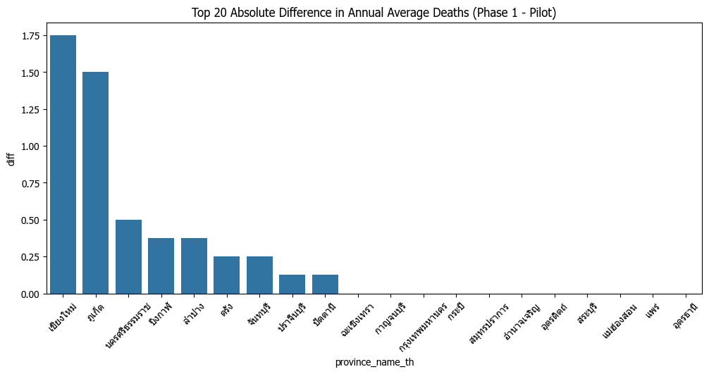

|  | province_name_th | deaths_abs_p1 | deaths_abs_pilot | diff |
| --- | --- | --- | --- | --- |
| 71 | เชียงใหม่ | 2.375 | 0.625 | 1.750 |
| 36 | ภูเก็ต | 1.625 | 0.125 | 1.500 |
| 19 | นครศรีธรรมราช | 2.625 | 2.125 | 0.500 |
| 24 | บึงกาฬ | 0.375 | 0.000 | 0.375 |
| 46 | ลำปาง | 0.875 | 0.500 | 0.375 |
| 12 | ตรัง | 0.875 | 0.625 | 0.250 |
| 6 | จันทบุรี | 1.750 | 1.500 | 0.250 |
| 28 | ปราจีนบุรี | 0.625 | 0.500 | 0.125 |
| 29 | ปัตตานี | 3.000 | 2.875 | 0.125 |
| 7 | ฉะเชิงเทรา | 0.375 | 0.375 | 0.000 |

```python
# Deaths Sanity Check
deaths_check = p1_df[['province_name_th', 'deaths_abs']].merge(
    pilot_df[['province_name_th', 'deaths_abs']],
    on='province_name_th',
    suffixes=('_p1', '_pilot')
)

deaths_check['diff'] = deaths_check['deaths_abs_p1'] - deaths_check['deaths_abs_pilot']

plt.figure(figsize=(12, 5))
sns.barplot(data=deaths_check.sort_values('diff', ascending=False).head(20), x='province_name_th', y='diff')
plt.xticks(rotation=45)
plt.title("Top 20 Absolute Difference in Annual Average Deaths (Phase 1 - Pilot)")
plt.show()

display(deaths_check.sort_values('diff', ascending=False).head(10))
```

### 3.3 Metric-Level Rank Correlation

We use Spearman Rank Correlation to examine how the relative standing of provinces changes when we shift data sources and definitions.

1. **GPP Comparison**: Comparing the rank of provinces by **Agricultural GPP (Pilot)** vs. **Total GPP (Phase 1)**. This reveals how much a province's economic profile shifts when considering only agriculture versus the entire economy (e.g., Bangkok).
2. **Affected Comparison**: Comparing the rank of provinces by **Casualties (Pilot: Deaths+Injured)** vs. **Affected Households (Phase 1)**. This shows if provinces with high physical harm also tend to be the ones with high social/household disruption.

```
Spearman Rank Correlation (GPP Total vs Agri): 0.4437
Spearman Rank Correlation (Households vs Casualties): 0.7906
```

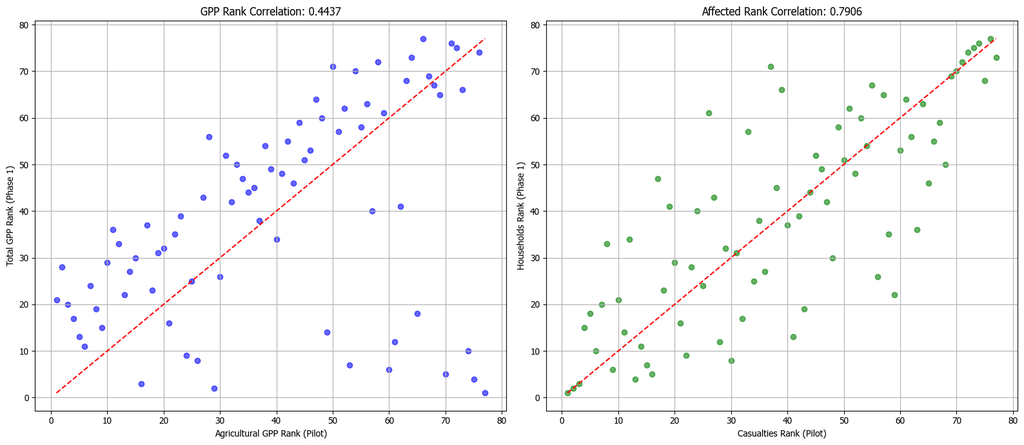

```python
from scipy.stats import spearmanr

# 1. GPP Rank Correlation
gpp_corr_df = p1_df[['province_name_th', 'gpp_total_p1']].merge(
    pilot_df[['province_name_th', 'gpp_agri_pilot']], on='province_name_th'
)
gpp_corr_df['rank_p1'] = gpp_corr_df['gpp_total_p1'].rank(ascending=False)
gpp_corr_df['rank_pilot'] = gpp_corr_df['gpp_agri_pilot'].rank(ascending=False)

gpp_corr, _ = spearmanr(gpp_corr_df['rank_p1'], gpp_corr_df['rank_pilot'])

# 2. Affected Rank Correlation
aff_corr_df = p1_df[['province_name_th', 'affected_abs']].merge(
    pilot_df[['province_name_th', 'affected_abs']], on='province_name_th', suffixes=('_p1', '_pilot')
)
aff_corr_df['rank_p1'] = aff_corr_df['affected_abs_p1'].rank(ascending=False)
aff_corr_df['rank_pilot'] = aff_corr_df['affected_abs_pilot'].rank(ascending=False)

aff_corr, _ = spearmanr(aff_corr_df['rank_p1'], aff_corr_df['rank_pilot'])

print(f'Spearman Rank Correlation (GPP Total vs Agri): {gpp_corr:.4f}')
print(f'Spearman Rank Correlation (Households vs Casualties): {aff_corr:.4f}')

# Visualization
fig, (ax1, ax2) = plt.subplots(1, 2, figsize=(16, 7))

ax1.scatter(gpp_corr_df['rank_pilot'], gpp_corr_df['rank_p1'], alpha=0.6, color='blue')
ax1.plot([1, 77], [1, 77], color='red', linestyle='--')
ax1.set_title(f'GPP Rank Correlation: {gpp_corr:.4f}')
ax1.set_xlabel('Agricultural GPP Rank (Pilot)')
ax1.set_ylabel('Total GPP Rank (Phase 1)')
ax1.grid(True)

ax2.scatter(aff_corr_df['rank_pilot'], aff_corr_df['rank_p1'], alpha=0.6, color='green')
ax2.plot([1, 77], [1, 77], color='red', linestyle='--')
ax2.set_title(f'Affected Rank Correlation: {aff_corr:.4f}')
ax2.set_xlabel('Casualties Rank (Pilot)')
ax2.set_ylabel('Households Rank (Phase 1)')
ax2.grid(True)

plt.tight_layout()
plt.show()
```

#### Analysis of Metric Correlations

The Spearman Rank Correlation results provide critical insights into the methodological transition from the Pilot to Phase 1:

1. **Human Impact Consistency ($\rho = 0.7906$):**
   - There is a **strong positive correlation** between the ranking of provinces by Casualties (Pilot) and Affected Households (Phase 1).
   - This suggests that physical harm and social disruption are geographically co-located.
   - **Conclusion**: Switching to "Affected Households" in Phase 1 is a valid and robust proxy for human vulnerability, as it maintains the same general risk distribution while using a more complete dataset.
2. **Economic Vulnerability Shift ($\rho = 0.4437$):**
   - There is only a **moderate correlation** between Agricultural GPP ranks and Total GPP ranks.
   - This confirms that a province's agricultural importance is not necessarily reflective of its total economic scale.
   - **Conclusion**: Moving from Agricultural GPP (Pilot) to Total GPP (Phase 1) as the denominator represents a fundamental shift in philosophy. The Phase 1 model treats climate impact as a burden on the **entire provincial economy**, whereas the Pilot was effectively an "Agricultural Risk Index." This explains the massive rank shifts for provinces like Bangkok, which are economically vital but agriculturally insignificant.

## 4. Pilot vs Phase 1 CRI Scores

[figure not shown]

```python
## 4.  Pilot vs Phase 1 CRI Scores
import geopandas as gpd
import matplotlib.pyplot as plt
import os

def _clean_code_2(series: pd.Series) -> pd.Series:
    s = series.astype(str).str.extract(r'(\d+)')[0].fillna('')
    return s.str[-2:].str.zfill(2)

# In order to merge by province_code, we need to load a dataset that maps province_name_th to province_code.
# The Phase 1 population table has both.
pop_lookup = p1_pop[["province_name_th", "province_code"]].drop_duplicates()
pop_lookup["province_code"] = _clean_code_2(pop_lookup["province_code"])

# Merge province_code into our scored dataframes
pilot_mapped = pilot_scored.merge(pop_lookup, on="province_name_th", how="left")
p1_mapped = p1_scored.merge(pop_lookup, on="province_name_th", how="left")

# Load province boundaries
shapefile_path = os.path.join(PHASE1_SILVER_DIR, "dopa/province_boundaries_enriched.shp")
gdf_prov = gpd.read_file(shapefile_path)
if gdf_prov.crs is None or gdf_prov.crs.to_epsg() != 4326:
    gdf_prov = gdf_prov.to_crs(epsg=4326)
gdf_prov = gdf_prov.copy()
gdf_prov['province_code'] = _clean_code_2(gdf_prov['prov_code'])

# Merge geometry with scores
gdf_pilot = gdf_prov.merge(pilot_mapped[["province_code", "pilot_cri_score"]], on="province_code", how="left")
gdf_p1 = gdf_prov.merge(p1_mapped[["province_code", "p1_cri_score"]], on="province_code", how="left")

# Plot side-by-side
fig, axes = plt.subplots(1, 2, figsize=(16, 12))

# Plot Pilot
axes[0].set_title("Pilot Phase CRI Score (OAE Relief + Total GPP)", fontsize=16)
axes[0].set_axis_off()
gdf_pilot.plot(
    column="pilot_cri_score",
    ax=axes[0],
    cmap="OrRd",
    legend=True,
    legend_kwds={'shrink': 0.6, 'fraction': 0.04, 'pad': 0.02},
    linewidth=0.4,
    edgecolor='#222222',
    missing_kwds={'color': '#f0f0f0', 'edgecolor': 'none', 'label': 'No data'}
)

# Plot Phase 1
axes[1].set_title("Phase 1 CRI Score(DDPM Relief + Total GPP)", fontsize=16)
axes[1].set_axis_off()
gdf_p1.plot(
    column="p1_cri_score",
    ax=axes[1],
    cmap="OrRd",
    legend=True,
    legend_kwds={'shrink': 0.6, 'fraction': 0.04, 'pad': 0.02},
    linewidth=0.4,
    edgecolor='#222222',
    missing_kwds={'color': '#f0f0f0', 'edgecolor': 'none', 'label': 'No data'}
)

plt.tight_layout()
plt.show()
```

## 5. Rank Stability & Contribution Analysis

To understand why the results changed, we analyze the **Rank Stability** of each indicator. A high Spearman Correlation indicates that the methodology change did not significantly alter the relative risk ranking for that metric, while a low correlation identifies the primary "disruptors" that drove the overall ranking shifts.

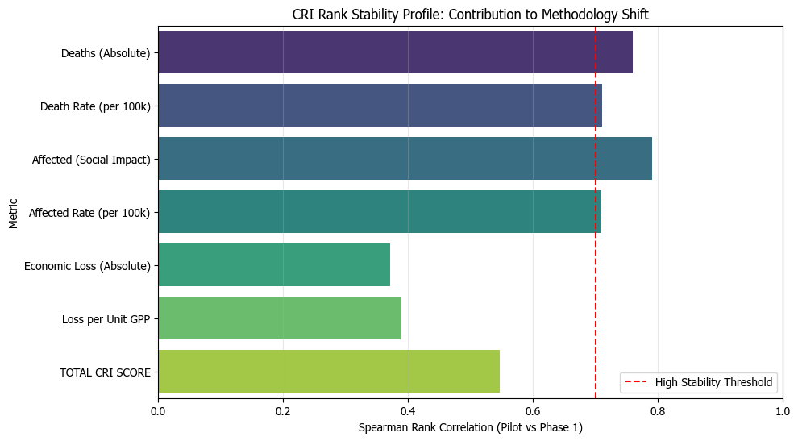

|  | Metric | Spearman Rho |
| --- | --- | --- |
| 2 | Affected (Social Impact) | 0.790578 |
| 0 | Deaths (Absolute) | 0.759317 |
| 1 | Death Rate (per 100k) | 0.710362 |
| 3 | Affected Rate (per 100k) | 0.708975 |
| 6 | TOTAL CRI SCORE | 0.546559 |
| 5 | Loss per Unit GPP | 0.388296 |
| 4 | Economic Loss (Absolute) | 0.371523 |

```python
from scipy.stats import spearmanr

# Define the 6 core indicators to compare
metrics = [
    ('deaths_abs', 'Deaths (Absolute)'),
    ('death_rate', 'Death Rate (per 100k)'),
    ('affected_abs', 'Affected (Social Impact)'),
    ('affected_rate', 'Affected Rate (per 100k)'),
    ('loss_abs', 'Economic Loss (Absolute)'),
    ('loss_rate', 'Loss per Unit GPP')
]

results = []

for col, label in metrics:
    # Create a temporary DF for ranking this specific metric
    temp_df = p1_df[['province_name_th', col]].merge(
        pilot_df[['province_name_th', col]],
        on='province_name_th', suffixes=('_p1', '_pilot')
    )

    # Rank both versions
    rank_p1 = temp_df[f'{col}_p1'].rank(ascending=False)
    rank_pilot = temp_df[f'{col}_pilot'].rank(ascending=False)

    # Calculate Spearman
    rho, _ = spearmanr(rank_p1, rank_pilot)
    results.append({'Metric': label, 'Spearman Rho': rho})

# Also calculate for the Final CRI Score
final_comp = p1_scored[['province_name_th', 'p1_rank']].merge(
    pilot_scored[['province_name_th', 'pilot_rank']],
    on='province_name_th'
)
final_rho, _ = spearmanr(final_comp['p1_rank'], final_comp['pilot_rank'])
results.append({'Metric': 'TOTAL CRI SCORE', 'Spearman Rho': final_rho})

stability_df = pd.DataFrame(results)

# Visualization
plt.figure(figsize=(10, 6))
sns.barplot(data=stability_df, x='Spearman Rho', y='Metric', palette='viridis')
plt.axvline(0.7, color='red', linestyle='--', label='High Stability Threshold')
plt.title('CRI Rank Stability Profile: Contribution to Methodology Shift')
plt.xlabel('Spearman Rank Correlation (Pilot vs Phase 1)')
plt.xlim(0, 1.0)
plt.legend()
plt.grid(axis='x', alpha=0.3)
plt.show()

display(stability_df.sort_values('Spearman Rho', ascending=False))
```

#### Interpretation of Contribution

- **High Stability (Rho > 0.7)**: Metrics in this range (likely Human Impact) indicate that the underlying risk distribution is preserved despite dataset changes. The transition to "Affected Households" and newer DDPM headcount data did not fundamentally change who is at risk.
- **Moderate to Low Stability (Rho < 0.6)**: These metrics are the primary drivers of the ranking shift. The low correlation in the **Economic Pillar (Loss and Loss Rate)** confirms that switching from Agricultural OAE data to Fiscal DDPM data fundamentally redefined economic climate risk for Thai provinces.

## 6. Interpretation of Discrepancies

Based on the quantitative audit and methodology review, the massive rank shifts are driven primarily by the **Economic Loss Proxy (Numerator)**.

### 1. The Numerator Shift: OAE vs. DDPM

The most significant driver of the discrepancy is the shift in the data source for `Loss_abs`:

- **Pilot (OAE)**: Represents agricultural compensation. In rural/agricultural provinces (like Nakhon Ratchasima, Chaiyaphum), these values can be massive because crop damage covers vast geographic areas.
- **Phase 1 (DDPM)**: Represents "เงินทดรองราชการ" (Government Advance Payment). This is an emergency budget used for immediate relief. It is historically capped (e.g., 20 million baht per province per disaster declaration). Therefore, even in a catastrophic flood, the DDPM reported financial loss will artificially hit a ceiling and appear much lower than the OAE agricultural loss.

**Impact:** Provinces heavily reliant on agriculture experienced a massive **Rank Drop** in Phase 1 because their astronomical OAE losses were replaced by capped, much smaller DDPM advance payments.

While secondary to the OAE vs DDPM proxy shift, the temporal window (2559-2566 vs 2560-2567) and the strict pipeline spatial roll-up rules in Phase 1 (handling of zero vs NaN) caused the remaining variations in Human Impact (Deaths and Affected).

## 7. Data Quality Audit: Affected People Sparsity

This section investigates the sparsity of headcount-based impact metrics (People) versus household-based metrics. In DDPM village-level reporting, headcount data is often under-reported or left as zero, while household impact is more consistently recorded for disaster compensation purposes.

```
--- Sparsity Audit (Village-Year-Hazard level) ---
Percentage of Records with Zero values:
deaths_sum                 95.636572
affected_people_sum        60.973159
affected_households_sum     4.062007
dtype: float64

Number of Non-Zero Records (out of total 6967):
deaths_sum                  304
affected_people_sum        2719
affected_households_sum    6684
dtype: int64
```

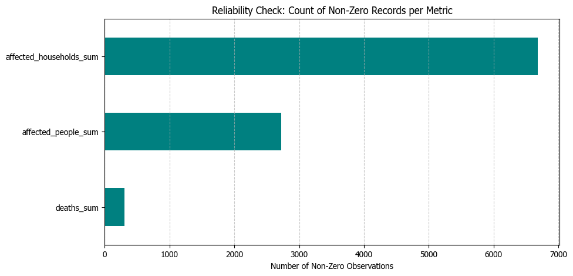

```
OBSERVATION:
Affected Households has 2.5x more data points than Affected People headcount.
This justifies the methodology choice to use Households as the primary proxy for social disruption.
```

```python
# Identify relevant impact columns in the Gold dataset (Verified from file header)
impact_cols = [
    'deaths_sum',
    'affected_people_sum',
    'affected_households_sum'
]

# 1. Calculate Sparsity (Percentage of Zeros)
sparsity = (p1_ddpm[impact_cols] == 0).mean() * 100

# 2. Calculate Non-Zero Event Counts
non_zero_counts = (p1_ddpm[impact_cols] > 0).sum()

print("--- Sparsity Audit (Village-Year-Hazard level) ---")
print("Percentage of Records with Zero values:")
print(sparsity)
print("\nNumber of Non-Zero Records (out of total {}):".format(len(p1_ddpm)))
print(non_zero_counts)

# 3. Comparative Visualization
plt.figure(figsize=(10, 5))
non_zero_counts.plot(kind='barh', color='teal')
plt.title('Reliability Check: Count of Non-Zero Records per Metric')
plt.xlabel('Number of Non-Zero Observations')
plt.grid(axis='x', linestyle='--', alpha=0.7)
plt.show()

print("\nOBSERVATION:")
if non_zero_counts['affected_households_sum'] > non_zero_counts['affected_people_sum']:
    ratio = non_zero_counts['affected_households_sum'] / non_zero_counts['affected_people_sum']
    print(f"Affected Households has {ratio:.1f}x more data points than Affected People headcount.")
    print("This justifies the methodology choice to use Households as the primary proxy for social disruption.")
```